# Week 6 - Simulation Project

Aman Arora

# 1 Simulation Study 1

## 1.1 Introduction

In this simulation we intend to study the impact of variance on the F statistic, p values and $R^2$ calculated from significant and non significant multiple regression values. Additionally we will compare and contrast the true distribution with empirical distrubitons from these 2 models.

## 1.2 Methods

In this simulation study we will investigate the significance of regression. We will simulate from two different models significant and non significant models. For both, we will consider a sample size of $25$ and three possible levels of noise. That is, three values of $\sigma$.

- $n = 25$
- $\sigma \in (1, 5, 10)$

The first model will be defined as follows:

1. The **“significant”** model (model 1)

$$Y_i = \beta_0 + \beta_1 x_{i1} + \beta_2 x_{i2} + \beta_3 x_{i3} + \epsilon_i$$

where $\epsilon_i \sim N(0, \sigma^2)$ and

- $\beta_0 = 3$,
- $\beta_1 = 1$,
- $\beta_2 = 1$,
- $\beta_3 = 1$.

```r
#set the  seed
birthday = 19771212
set.seed(birthday)

#Read in the data
df1 = read.csv("study_1.csv")

#No of simulations
m = 2000

# No of observations
n = nrow(df1)

#No of parameters of the significant model
p = 4

#Function to Simulate MLR
sim_mlr = function(df, betas, sigma) {
  n = nrow(df)
  X = cbind(x0 = rep(1, n), as.matrix(df[-1]))
  epsilon = rnorm(n, mean = 0, sd = sigma)
  Y = X %*% betas + epsilon
  df["y"] = Y
  return(df)
}

#Sigmas to be simulated
sigmas = c(1, 5, 10)

#Model 1 - significant model betas
betas1 = c(3, 1, 1, 1)

#Initialize matrices to store results for model 1
f_stat_1 = matrix(0, m, length(sigmas))
p_val_1 =  matrix(0, m, length(sigmas))
r_squared_1 = matrix(0, m, length(sigmas))


#Simulate MLR 2000 times for each sigma and store results in a matrix.
for (j in 1:length(sigmas))
{
  for (i in 1:m)
  {
    #Simulate MLR
    df1 = sim_mlr(df1, betas1, sigmas[j])

    # Fit the model and store its summary
    model_fitted_sum = summary(lm(y ~ x1 + x2 + x3, data = df1))

    #Store f statistic, r squared and p value for this simulation
    f_stat_1[i, j] = model_fitted_sum$fstatistic["value"]
    r_squared_1[i, j] = model_fitted_sum$r.squared
    p_val_1[i, j] = pf(f_stat_1[i, j], p - 1, n - p, lower.tail = FALSE)
  }
}
```

Now we will simulate the second model, it will be non-significant model with betas for all predictors set to 0, It will defined as follows:

2. The **“non-significant”** model (model 2)

$$Y_i = \beta_0 + \beta_1 x_{i1} + \beta_2 x_{i2} + \beta_3 x_{i3} + \epsilon_i$$

where $\epsilon_i \sim N(0, \sigma^2)$ and

- $\beta_0 = 3$,
- $\beta_1 = 0$,
- $\beta_2 = 0$,
- $\beta_3 = 0$.

```r
#Model 2

#Read in the data
df1 = read.csv("study_1.csv")

#No of simulations
m = 2000

# No of observations
n = nrow(df1)

#No of parameters of the significant model
p = 4

#Sigmas to be simulated
sigmas = c(1, 5, 10)

#betas
betas = c(3,0,0,0)

#Initialize matrices to store results for model 2
f_stat_2 = matrix(0, m, length(sigmas))
p_val_2 =  matrix(0, m, length(sigmas))
r_squared_2 = matrix(0, m, length(sigmas))

#Simulate MLR for each sigma and store results
for(j in 1:length(sigmas))
{
  for (i in 1:m)
  {
    df1 = sim_mlr(df1,betas,sigmas[j])
    model_fitted_sum = summary(lm(y ~ x1+x2+x3, data = df1) )
    f_stat_2[i,j] = model_fitted_sum$fstatistic["value"]
    r_squared_2[i,j]= model_fitted_sum$r.squared
    p_val_2[i,j] = pf(f_stat_2[i,j],p-1,n-p,lower.tail = FALSE)
  }
}
```

## 1.3 Results

### 1.3.1 Comparison of means

#### 1.3.1.1 Significant Model

|  | sigma = 1 | sigma = 5 | sigma = 10 |
| --- | --- | --- | --- |
| P value mean | 0.0000 | 0.2100 | 0.4004 |
| F-statistic mean | 41.7898 | 2.7263 | 1.5299 |
| R squared mean | 0.8415 | 0.2535 | 0.1619 |

#### 1.3.1.2 Non Significant Model

|  | sigma = 1 | sigma = 5 | sigma = 10 |
| --- | --- | --- | --- |
| P value mean | 0.5057 | 0.5040 | 0.5023 |
| F-statistic mean | 1.1042 | 1.1200 | 1.0985 |
| R squared mean | 0.1244 | 0.1253 | 0.1243 |

### 1.3.2 Mean of p values with sigma

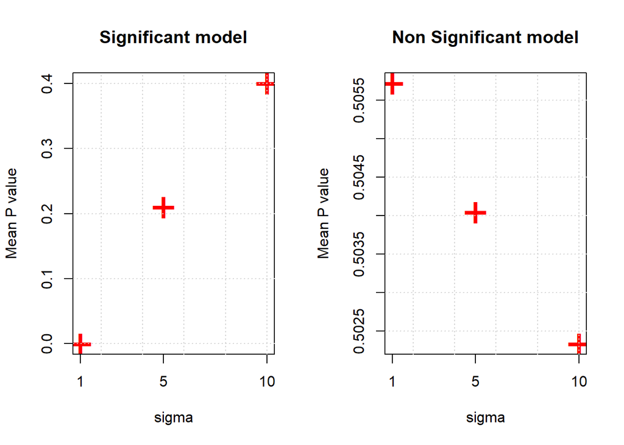

#### 1.3.2.1 Histograms of R squared for different Variances for Significant (Model 1) & non insignificant models (Model 2)

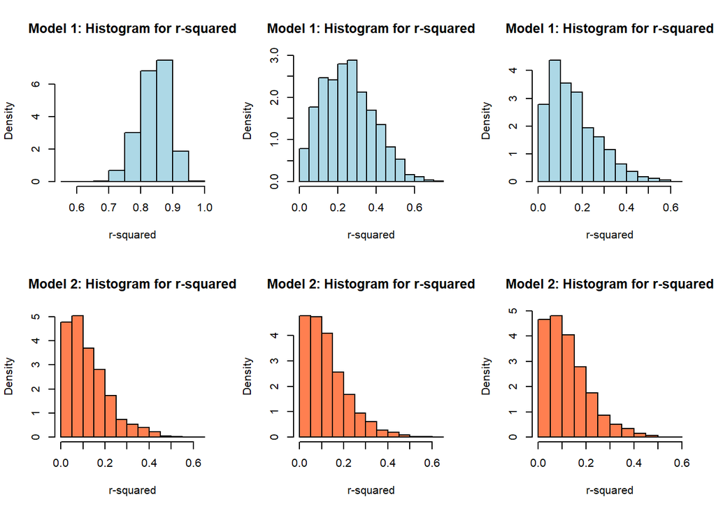

#### 1.3.2.2 Histograms of p values for different Variances for Significant (Model 1) non insignificant models (Model 2)

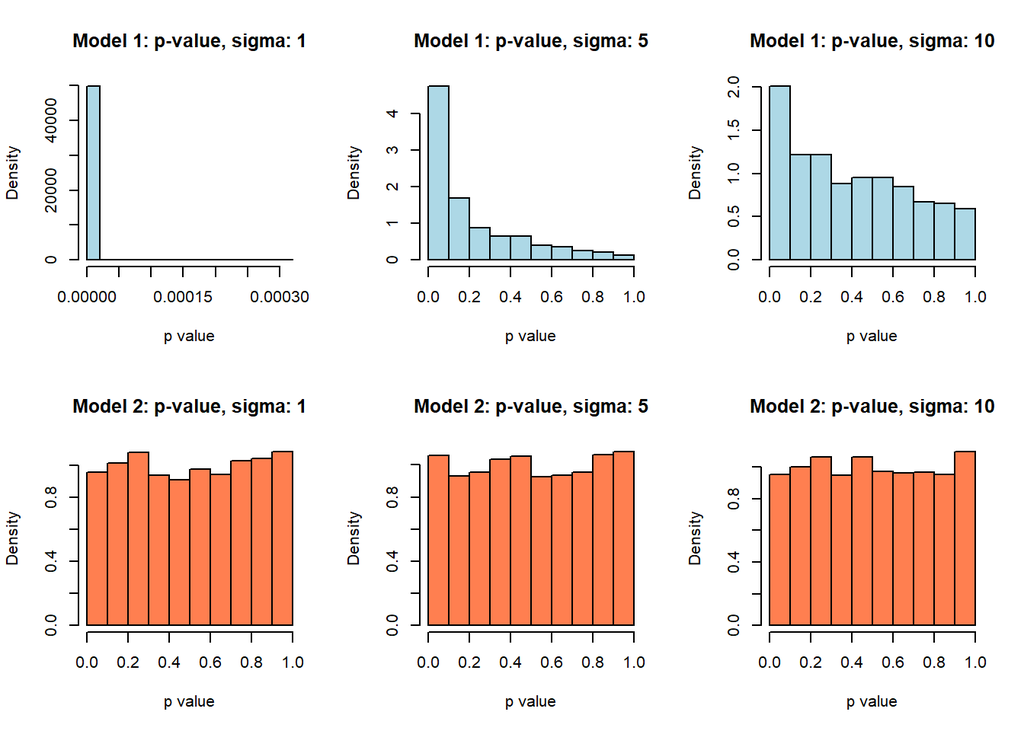

#### 1.3.2.3 Histograms of f statistic for different Variances for Significant (Model 1) non insignificant models (Model 2).

True distribution for F-statistic added for Model 2 (red line)

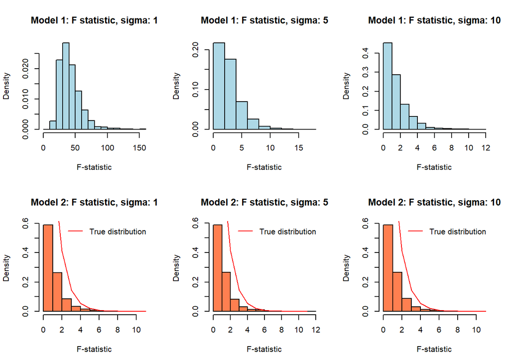

## 1.4 Discussion

# 2 Simulation Study 2

## 2.1 Introduction

In this simulation we intend to study the effect of model size/variance on test and train RMSE for a linear model. We will also quantify how frequently the actual model is selected by using test RMSE as the criteria.

## 2.2 Methods

```r
df1 = read.csv("study_2.csv")
#No of simulations
m = 500
library(knitr)
set.seed(19771212)
```

```r
#Function to Simulate MLR
sim_mlr = function(df, betas, sigma) {
  n = nrow(df)
  X = cbind(x0= rep(1,n), as.matrix(df[2:7]))
  epsilon = rnorm(n, mean = 0, sd = sigma)
  Y = X %*% betas + epsilon
  df["y"] = Y
  return(df)
}
```

```r
#Function to calculate and return training RMSE and test RMSE for a model
evaluate_model <-function(fitted_model,train_data, test_data)
{

 rmse_train = sqrt(mean(fitted_model$residuals^2))

 new_data1 = test_data[,names(fitted_model$model)][-1]

 y_test_pred = predict(fitted_model, newdata = new_data1)

 residual_test =   as.vector(y_test_pred - as.vector(test_data["y"]))[,1]

 rmse_test  = sqrt(mean(residual_test^2))

 result = c(rmse_train, rmse_test)

}
```

```r
#Function to simulate a run for a given sigma and beta
simulate_run <-function(df, betas, sigma, num_sim = 1000 )
{

 min_count = rep(0,9)

 result_train = matrix(0, 9, num_sim)
 result_test = matrix(0, 9, num_sim)

 #Create the model
 response = "y"
 predictors = c("x1","x2","x3","x4","x5","x6","x7","x8","x9")

 #Run 1000 simulations
 for(q in 1:num_sim)
 {
  #Simulate MLR
  df = sim_mlr(df,betas,sigma)

  #Split training and test data
  trn_idx = sample(1:nrow(df), 250)
  tst_idx = setdiff(1:nrow(df), trn_idx)
  trn_data = df[trn_idx,]
  tst_data  = df[tst_idx,]

  #initialize test RMSE to a large value
  min_model = 10^6

  #Run linear regression on 9 models, evaluate and store RMSE  for test and training data
  for(model_num  in 1:9)
  {
    f = as.formula(paste (response, paste(predictors[1:model_num],collapse = "+"),sep = "~"))
    #print(f)

    #Fit the model and find test and train RMSE
    model_true = lm(f ,data = trn_data)
    result = evaluate_model(model_true,trn_data,tst_data)
    result_train[model_num,q] = result[1]
    result_test[model_num,q] = result[2]

    #Compare test RMSE with best so far
    min_model = min(min_model, result[2])

    #update the best model based on test RMSE
    if (min_model == result[2])
    {
      best_model_idx = model_num

    }
  }

  #update the count of best model
  min_count[best_model_idx] = min_count[best_model_idx] + 1
 }

 result = list(rowMeans(result_train), rowMeans(result_test), min_count)

 names(result) = c("train_rmse", "test_rmse", "counts")
 return (result )

}
```

```r
#sigmas to be simulated
sigmas = c(1,2,4)

#Model betas
betas1 = c(0,3,-4,1.6,-1.1,0.7,0.5)


#Run simualtion for 3 different sigmas
result_sigma1 =  simulate_run(df = df1, betas = betas1, sigma = sigmas[1], num_sim = 1000 )

result_sigma2 =  simulate_run(df = df1, betas = betas1, sigma = sigmas[2], num_sim = 1000 )

result_sigma4 =  simulate_run(df = df1, betas = betas1, sigma = sigmas[3], num_sim = 1000 )
```

## 2.3 Results

### 2.3.1 Model no. wins vs model number

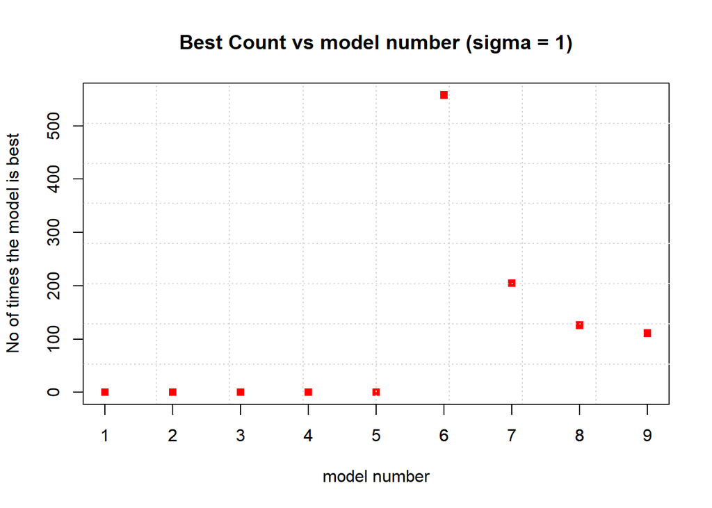

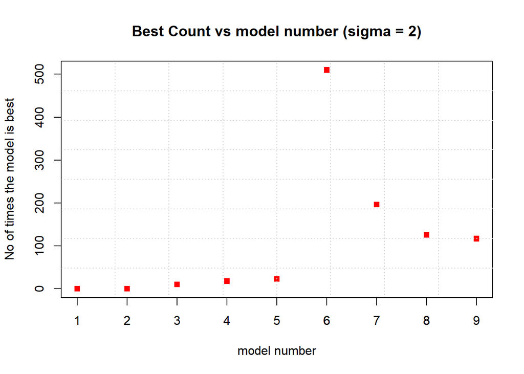

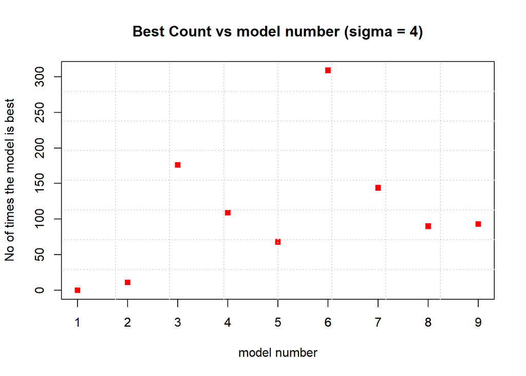

### 2.3.2 Mean Train/Test RMSE

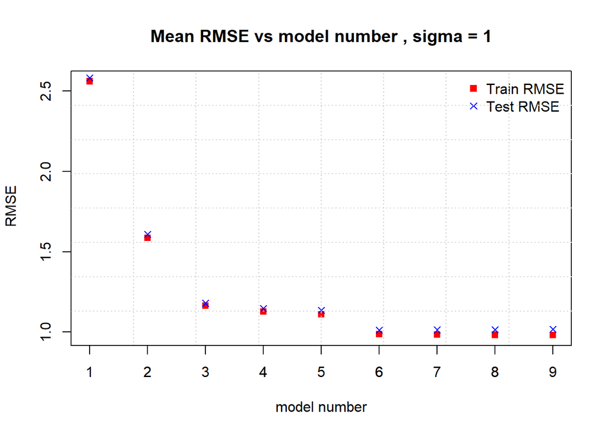

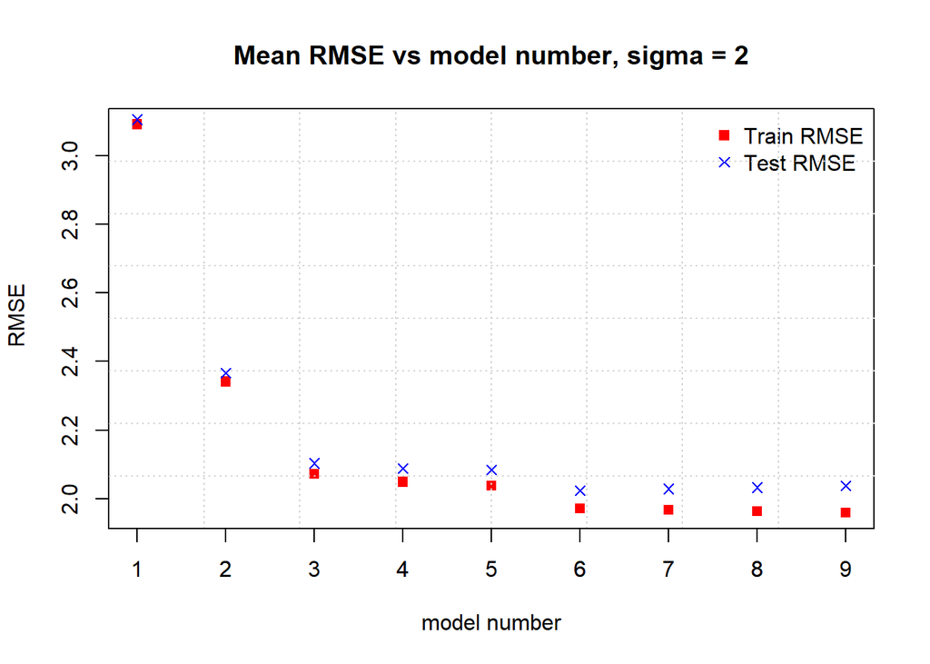

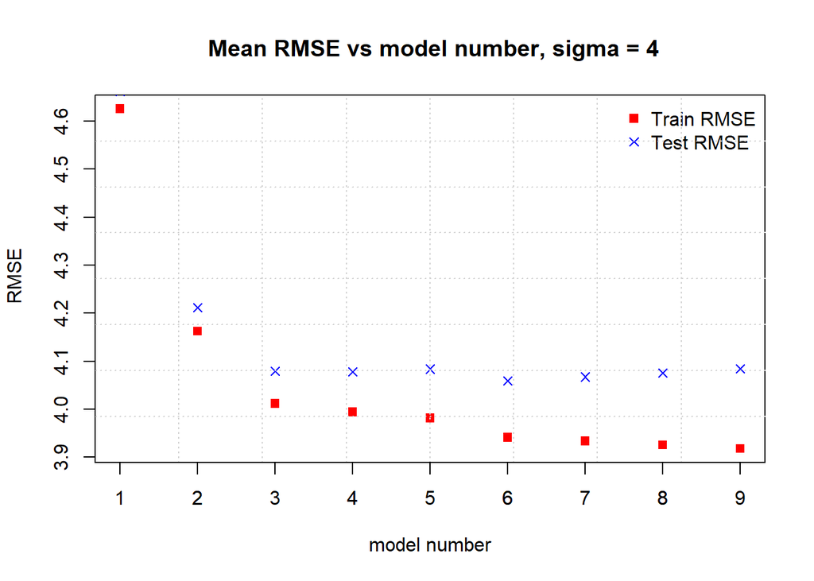

## 2.4 Discussion

# 3 Simulation Study 3: Power

## 3.1 Introduction

In this simulation study we will investigate the power of the significance of regression test defined as the probability of rejecting the NULL hypothesis when NULL hypothesis is false. We will also study for SLR how power is affected by sample size, variance and signal strength ($\beta_1$).

## 3.2 Methods

```r
#Function to Simulate SLR
sim_slr = function(x, beta_0 , beta_1, sigma) {
  n = length(x)
  epsilon = rnorm(n, mean = 0, sd = sigma)
  y = beta_0 + beta_1 * x + epsilon
  data.frame(predictor = x, response = y)
}
```

```r
set.seed(19771212)
beta1_list = seq(from = -2, to = 2, by = .1)

sigmas = c(1,2,4)
alpha = 0.05
sample_list  = c(10,20,40)
num_sim = 1000
p_val = rep(0,num_sim)

results <- array(rep(0, length(sample_list)*length(sigmas)*length(beta1_list)), dim=c(length(beta1_list), length(sigmas), length(sample_list)))

for(beta1_idx in 1:length(beta1_list))
{


  #cat("beta1_idx:", beta1_idx, "beta1_list",beta1_list[beta1_idx], "\n")
  for(sigma_idx in 1:length(sigmas))
  {
    for(n_idx in 1:length(sample_list))
    {
      x_values = seq(0, 5, length = sample_list[n_idx])
      null_rej_count  = 0
      for(i in 1:num_sim)
      {
        df1 = sim_slr(x_values,0,beta1_list[beta1_idx],sigmas[sigma_idx])
        model_sum = summary(lm(predictor~response, data = df1))
        p_val[i] = model_sum$coefficients["response","Pr(>|t|)"]
        #print(p_val)
        if(p_val[i] < alpha)
        {
          null_rej_count =  null_rej_count +1
          #cat("null reject_count", null_rej_count,"\n")
        }
      }
      results[beta1_idx,sigma_idx,n_idx] = null_rej_count/num_sim
    }
  }
}
```

## 3.3 Results

### 3.3.1 Power vs signal curves

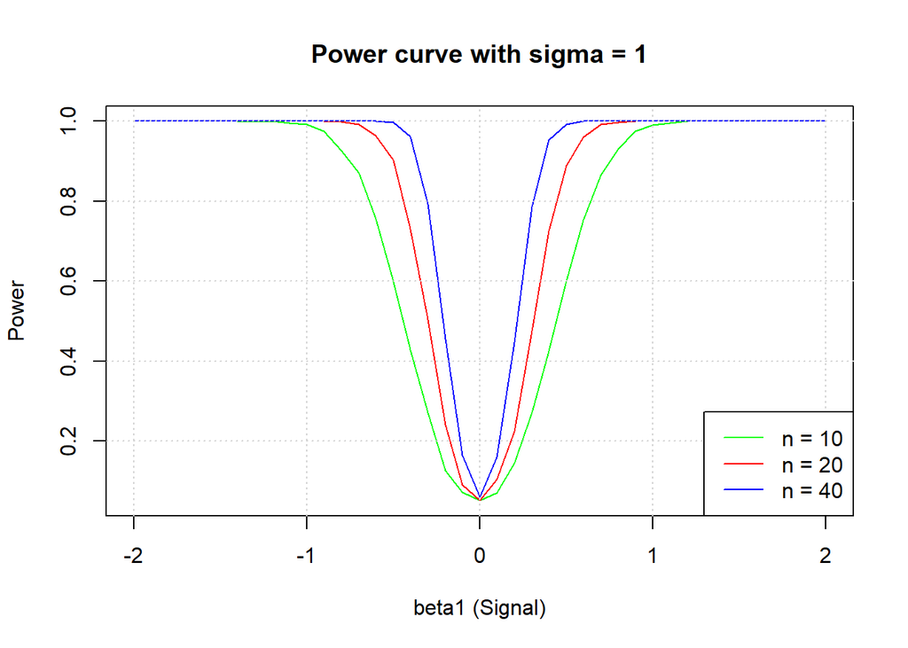

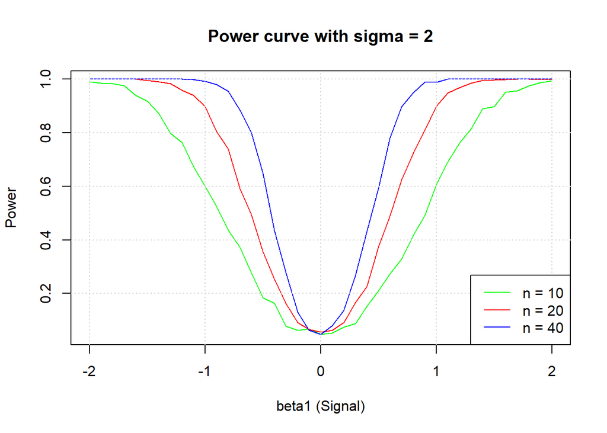

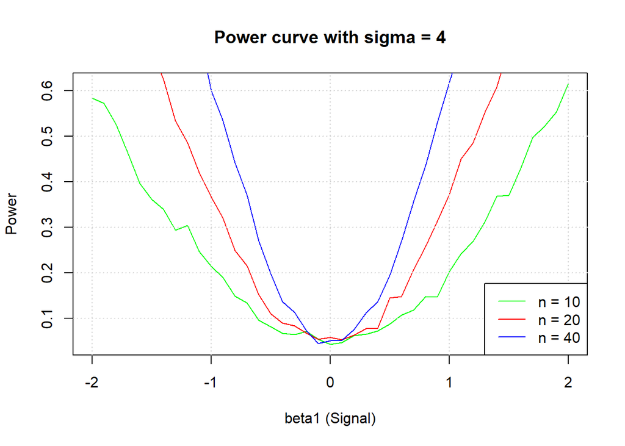

## 3.4 Discussion

- As we can see from the plots Power vs signal curves above with same signal ($\beta_1$) the power increase with sample size.
- The standard deviation $\sigma$ seems to have detrimental effect on the power as seen from plot Mean Power vs sigma .The mean power (averaged across beta) decreases as the standard deviation increases for all sample size

### 3.4.1 Mean Power vs sigma

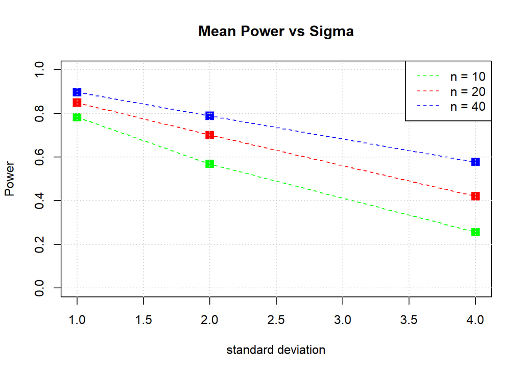

### 3.4.2 Power vs Signal to noise ratio

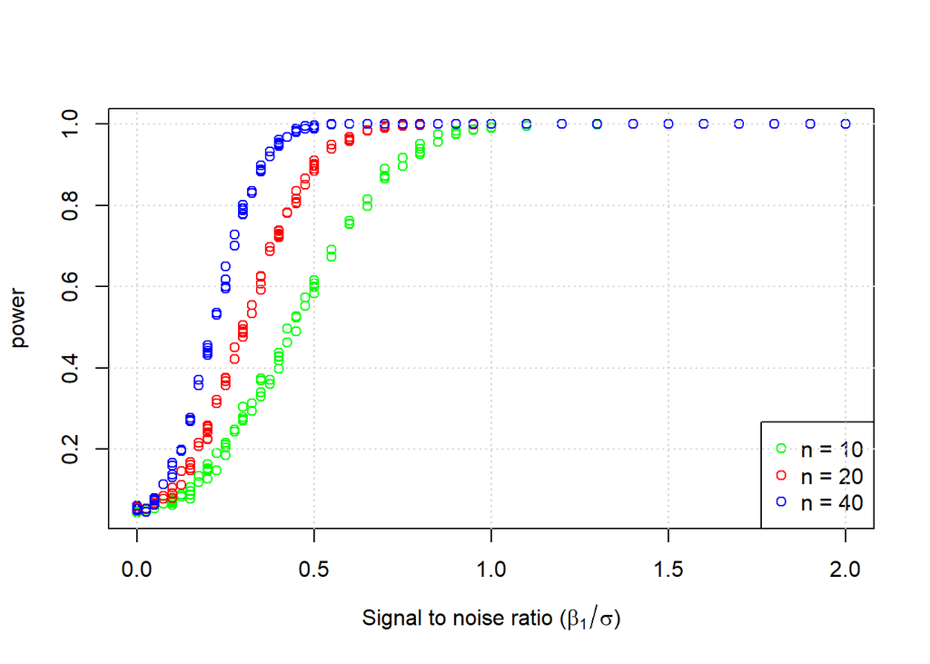

- Moreover as seen from Power vs Signal to noise ratio signal magnitude had a positive effect on power, with increased signal magnitude (for same sd) the power tends to increase, more specifically its the signal to noise ratio defined as snr = $|\frac {\beta_1} {\sigma}|$ that improves the power of the regression. Also with increasing sample size the power is improving, lower sample size increases the uncertainty (increased sample variance) it acts like noise and contributes to the lower power.

### 3.4.3 P value Histogram

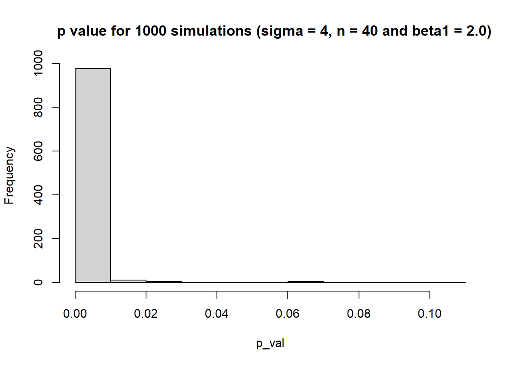

- 1000 simulations seems to be sufficient since we can see from p_val histogram P value Histogram for a run (sigma = 4, n = 40 and $\beta_1$ = 2.0) there seems to be single mode and the simulated p values seems to have converged. There seems to agreement among the generated p value from simulation. This is also indicated by low standard deviation 0.007 in generated p values. It seems additional simulations will not change the conclusions.